# Extended example: the litters model

NIMBLE training materials module

NIMBLE Development Team

# Introduction

Here we’ll work through an extended example of customizing an MCMC for a tricky, but simple, example model.

The example is the *litters* example from the original BUGS examples, available with NIMBLE in the *classic-bugs/vol1/litters* directory of the installed package (call `searchpaths()` after loading the NIMBLE package to find where this directory is).

# Litters model

Here’s the original litters model. There are `G=2` groups of rat litters, with `N=16` litters (i.e., mothers) in each group, and a variable number of pups in each litter. Survival of the pups in a litter is governed by a survival probability for each litter, `p[i,j]`, but the probabilities for the litters within a group are considered to come from a common distribution, thereby borrowing strength across the litters in a group.

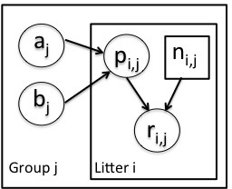

Here’s the BUGS code.

```r
code <- nimbleCode({
  for (i in 1:G) {
     for (j in 1:N) {
         # likelihood (data model)
        r[i,j] ~ dbin(p[i,j], n[i,j])
    # latent process (random effects)
        p[i,j] ~ dbeta(a[i], b[i])
     }
     # prior for hyperparameters
     a[i] ~ dgamma(1, .001)
     b[i] ~ dgamma(1, .001)
   }
})
```

# Set up the model

```r
consts <- list(G = 2,N = 16, n = matrix(c(13, 12, 12, 11, 9, 10,
       9, 9, 8, 11, 8, 10, 13, 10, 12, 9, 10, 9, 10, 5, 9, 9, 13,
       7, 5, 10, 7, 6, 10, 10, 10, 7), nrow = 2))
data = list(r = matrix(c(13, 12, 12, 11, 9, 10, 9, 9, 8, 10, 8, 9,
     12, 9, 11, 8, 9, 8, 9, 4, 8, 7, 11, 4, 4, 5, 5, 3, 7, 3, 7, 0),
     nrow = 2))
inits <- list( a = c(2, 2), b=c(2, 2) )
model <- nimbleModel(code, constants = consts, data = data, inits = inits)
```

```
## defining model...
```

```
## building model...
```

```
## setting data and initial values...
```

```
## running calculate on model (any error reports that follow may simply
## reflect missing values in model variables) ...
```

```
## checking model sizes and dimensions...
```

```
## note that missing values (NAs) or non-finite values were found in model
## variables: p. This is not an error, but some or all variables may need to
## be initialized for certain algorithms to operate properly.
```

```
## model building finished.
```

# Basic MCMC

Here’s NIMBLE’s default MCMC.

```r
thin <- 10
conf <- configureMCMC(model, thin = thin)
# thinning _only_ to reduce time of plotting
#  (thinning is proven to always reduce efficiency in parameter estimation)
conf$addMonitors(c('a', 'b', 'p'))
```

```
## thin = 10: a, b, p
```

```r
mcmc <- buildMCMC(conf)

Cmodel <- compileNimble(model)
```

```
## compiling... this may take a minute. Use 'showCompilerOutput = TRUE' to see C++ compiler details.
```

```
## compilation finished.
```

```r
Cmcmc <- compileNimble(mcmc, project = model)
```

```
## compiling... this may take a minute. Use 'showCompilerOutput = TRUE' to see C++ compiler details.
## compilation finished.
```

```r
niter <- 10000
set.seed(0)
system.time(Cmcmc$run(niter))
```

```
## |-------------|-------------|-------------|-------------|
## |-------------------------------------------------------|
```

```
##    user  system elapsed
##   0.581   0.000   0.580
```

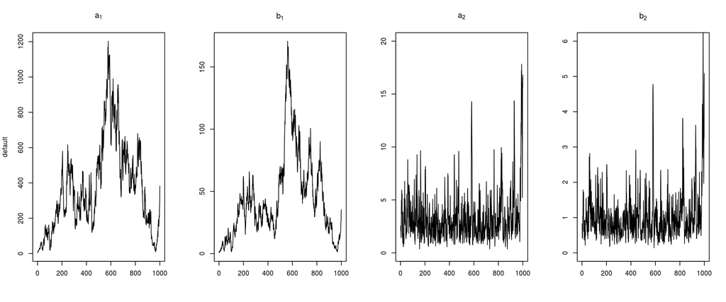

```r
smp_basic <- as.matrix(Cmcmc$mvSamples)

par(mfrow = c(1, 4))
ts.plot(smp_basic[ , 'a[1]'], main = expression(a[1]), xlab = '', ylab = 'default')
ts.plot(smp_basic[ , 'b[1]'], main = expression(b[1]), xlab = '', ylab = '')
ts.plot(smp_basic[ , 'a[2]'], main = expression(a[2]), xlab = '', ylab = '', ylim = c(0,20))
ts.plot(smp_basic[ , 'b[2]'], main = expression(b[2]), xlab = '', ylab = '', ylim = c(0,6))
```

```r
library(coda)
nBurn <- niter / 5
postBurn <- (nBurn:niter) / thin
effectiveSize(as.mcmc(smp_basic[postBurn, ]))
```

```
##       a[1]       a[2]       b[1]       b[2]    p[1, 1]    p[2, 1]
##   6.809127  76.189001   3.736584  81.561442  68.799873 618.340021
##    p[1, 2]    p[2, 2]    p[1, 3]    p[2, 3]    p[1, 4]    p[2, 4]
##  87.879795 576.180101  86.778718 643.077566  78.422494 476.649908
##    p[1, 5]    p[2, 5]    p[1, 6]    p[2, 6]    p[1, 7]    p[2, 7]
##  90.792847 855.996368  85.537502 735.292485 108.808159 954.357652
##    p[1, 8]    p[2, 8]    p[1, 9]    p[2, 9]   p[1, 10]   p[2, 10]
## 107.707596 668.443428  90.441679 927.722137  79.400157 813.378445
##   p[1, 11]   p[2, 11]   p[1, 12]   p[2, 12]   p[1, 13]   p[2, 13]
##  99.248058 790.945718 112.038294 602.384351 113.408286 674.353162
##   p[1, 14]   p[2, 14]   p[1, 15]   p[2, 15]   p[1, 16]   p[2, 16]
##  94.355115 803.616393  91.737381 467.313694  98.669997 216.728707
```

# Blocking the hyperparameters

Given the posterior correlation between the hyperparameters for each group, an obvious first step is to try (separate) block samplers on `a[1],b[1]}` and `{a[2],b[2]}`.

```r
conf$removeSamplers(c('a', 'b'))
conf$addSampler(c('a[1]', 'b[1]'), 'RW_block')
conf$addSampler(c('a[2]', 'b[2]'), 'RW_block')

mcmc <- buildMCMC(conf)
Cmcmc <- compileNimble(mcmc, project = model, resetFunctions = TRUE)
```

```
## compiling... this may take a minute. Use 'showCompilerOutput = TRUE' to see C++ compiler details.
```

```
## compilation finished.
```

```r
nimCopy(model, Cmodel)  # reinitialize

niter <- 10000
set.seed(0)
system.time(Cmcmc$run(niter))
```

```
## |-------------|-------------|-------------|-------------|
## |-------------------------------------------------------|
```

```
##    user  system elapsed
##   0.484   0.000   0.482
```

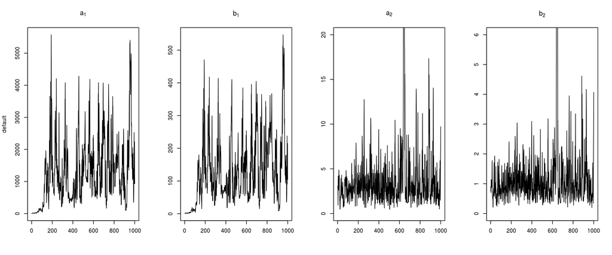

```r
smp_hyp_block <- as.matrix(Cmcmc$mvSamples)

par(mfrow = c(1, 4))
ts.plot(smp_hyp_block[ , 'a[1]'], main = expression(a[1]), xlab = '', ylab = 'default')
ts.plot(smp_hyp_block[ , 'b[1]'], main = expression(b[1]), xlab = '', ylab = '')
ts.plot(smp_hyp_block[ , 'a[2]'], main = expression(a[2]), xlab = '', ylab = '', ylim = c(0,20))
ts.plot(smp_hyp_block[ , 'b[2]'], main = expression(b[2]), xlab = '', ylab = '', ylim = c(0,6))
```

```r
effectiveSize(as.mcmc(smp_hyp_block[postBurn, ]))
```

```
##       a[1]       a[2]       b[1]       b[2]    p[1, 1]    p[2, 1]
##   47.06260   53.43642   43.87060   52.77214   18.06401  581.10838
##    p[1, 2]    p[2, 2]    p[1, 3]    p[2, 3]    p[1, 4]    p[2, 4]
##   20.25218  528.10511   21.03731  367.92359   14.57052  510.19189
##    p[1, 5]    p[2, 5]    p[1, 6]    p[2, 6]    p[1, 7]    p[2, 7]
##   21.00124  939.45719   18.72152  957.65675   20.37574  771.74204
##    p[1, 8]    p[2, 8]    p[1, 9]    p[2, 9]   p[1, 10]   p[2, 10]
##   19.06157  712.58189   20.18958  814.96585   21.28980 1130.17762
##   p[1, 11]   p[2, 11]   p[1, 12]   p[2, 12]   p[1, 13]   p[2, 13]
##   19.82625 1098.87401   21.63361  567.11726   20.38140  557.42640
##   p[1, 14]   p[2, 14]   p[1, 15]   p[2, 15]   p[1, 16]   p[2, 16]
##   21.74204  551.43485   18.34889  504.13723   22.46543  220.37961
```

# Blocking the random effects too

But perhaps we should have blocked the hyperparameters with their dependent random effects. This is how one could do that, though `a`, `b`, and `p` are on very different scales, which may cause problems, particularly at the start of an adaptive sampler. As we see in the trace plots, this strategy is not working at all.

```r
conf$removeSamplers(c('a', 'b', 'p'))
group1nodes <- model$getDependencies(c('a[1]', 'b[1]'), stochOnly = TRUE)
group2nodes <- model$getDependencies(c('a[2]', 'b[2]'), stochOnly = TRUE)
conf$addSampler(group1nodes, 'RW_block')
conf$addSampler(group2nodes, 'RW_block')

mcmc <- buildMCMC(conf)
Cmcmc <- compileNimble(mcmc, project = model, resetFunctions = TRUE)
```

```
## compiling... this may take a minute. Use 'showCompilerOutput = TRUE' to see C++ compiler details.
```

```
## compilation finished.
```

```r
niter <- 10000
nimCopy(model, Cmodel)  # reinitialize

set.seed(0)
system.time(Cmcmc$run(niter))
```

```
## |-------------|-------------|-------------|-------------|
## |-------------------------------------------------------|
```

```
##    user  system elapsed
##   0.364   0.308   0.336
```

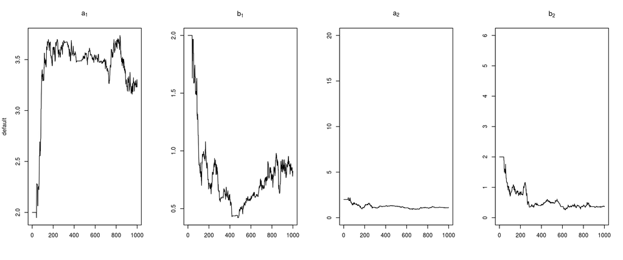

```r
smp_full_block <- as.matrix(Cmcmc$mvSamples)

par(mfrow = c(1,4))
ts.plot(smp_full_block[ , 'a[1]'], main = expression(a[1]), xlab = '', ylab = 'default')
ts.plot(smp_full_block[ , 'b[1]'], main = expression(b[1]), xlab = '', ylab = '')
ts.plot(smp_full_block[ , 'a[2]'], main = expression(a[2]), xlab = '', ylab = '', ylim = c(0,20))
ts.plot(smp_full_block[ , 'b[2]'], main = expression(b[2]), xlab = '', ylab = '', ylim = c(0,6))
```

More generally, in any model, we might ask if we have the ideal blocking structure? Even in simple models, there is a combinatorial explosion of possible blocks. Sometimes we have some intuition and can do this manually, but sometimes that is a lot of work.

# Automated blocking

The NIMBLE developers have developed a procedure for automated blocking in MCMC, based on considering the posterior correlation of all parameters in initial trial runs of the MCMC, as discussed [here](http://arxiv.org/abs/1503.05621).

Let’s try automated blocking for this model.

```r
auto <- autoBlock(model, autoIt = 10000, run = list())
```

```
## running calculate on model (any error reports that follow may simply
## reflect missing values in model variables) ...
```

```
## checking model sizes and dimensions...
```

```
## note that missing values (NAs) or non-finite values were found in model
## variables: r, p, a, b. This is not an error, but some or all variables may
## need to be initialized for certain algorithms to operate properly.
```

```
## compiling... this may take a minute. Use 'showCompilerOutput = TRUE' to see C++ compiler details.
```

```
## compilation finished.
```

```
## compiling... this may take a minute. Use 'showCompilerOutput = TRUE' to see C++ compiler details.
```

```
## compilation finished.
```

```
## compiling... this may take a minute. Use 'showCompilerOutput = TRUE' to see C++ compiler details.
```

```
## compilation finished.
```

```
## |-------------|-------------|-------------|-------------|
## |-------------------------------------------------------|
```

```
## compiling... this may take a minute. Use 'showCompilerOutput = TRUE' to see C++ compiler details.
## compilation finished.
```

[output not shown]

```
## compiling... this may take a minute. Use 'showCompilerOutput = TRUE' to see C++ compiler details.
## compilation finished.
```

```
## |-------------|-------------|-------------|-------------|
## |-------------------------------------------------------|
## |-------------|-------------|-------------|-------------|
## |-------------------------------------------------------|
## |-------------|-------------|-------------|-------------|
## |-------------------------------------------------------|
## |-------------|-------------|-------------|-------------|
## |-------------------------------------------------------|
## |-------------|-------------|-------------|-------------|
## |-------------------------------------------------------|
## |-------------|-------------|-------------|-------------|
## |-------------------------------------------------------|
## |-------------|-------------|-------------|-------------|
## |-------------------------------------------------------|
## |-------------|-------------|-------------|-------------|
## |-------------------------------------------------------|
## |-------------|-------------|-------------|-------------|
## |-------------------------------------------------------|
## |-------------|-------------|-------------|-------------|
## |-------------------------------------------------------|
##
## Auto-Blocking summary:
##            mcmc    node     S    C Efficiency
## 1    All Scalar    a[1] 17.27 0.46      37.78
## 2 Auto-Blocking p[1, 7] 39.27 0.36     108.18
##
## Auto-Blocking converged on the node groupings:
## [1] a[1], b[1]
## [2] a[2], b[2]
## [3] p[1, 13], p[1, 15]
```

```r
confAuto <- auto$conf
mcmc <- buildMCMC(confAuto)
```

Given how similar the blocking is to simply blocking the hyperparameters, we won’t bother trying it here, but it’s easy to do since *autoBlock()* returns an MCMC configuration argument that can be fed into buildMCMC.

# Integrating over the random effects: user-defined distribution

One common cause of poor MCMC performance is dependence across the levels of a model, such as between hyperparameters and the random effects that depend on those hyperparameters. Such dependence may not be effectively addressed using simple blocking.

When one has conjugacy, as in this case for the `p` parameters, one can always analytically integrate over those parameters in the model. By reducing dimensionality this can often improve MCMC efficiency though it removes conjugacy, which can also hurt.

Here’s the graph for the model after integrating over the `p` parameters.

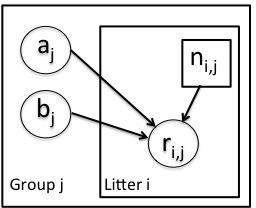

One of the major drawbacks is the need to do the integration, which users not familiar with probability may not be able to do easily. That said, let’s consider it in this example, by using a user-defined *beta-binomial* distribution. This is the distribution for *y* that results from integrating over *p*.

Actually, given that the module on user-defined distributions provides a Dirichlet-multinomial distribution and the beta-binomial distribution is the special case of that with only two categories, we could just borrow that code. See the module user_dist for details and sample code.

# Implicitly integrating over the random effects: cross-level sampler

An easier alternative to analytically integrating over the random effects is to use a computational trick that mathematically achieves the same result.

The idea of what we call the *cross-level sampler* is:

- do a blocked Metropolis random walk on one or more hyperparameters and then a conjugate update of the dependent nodes conditional on the proposed hyperparameters, accepting/rejecting everything together
- this amounts to a joint update of the hyperparameters and their dependent nodes
- equivalent to analytically integrating over the dependent nodes

```r
conf$removeSamplers(c('a', 'b', 'p'))
conf$addSampler(c('a[1]', 'b[1]'), 'crossLevel')
conf$addSampler(c('a[2]', 'b[2]'), 'crossLevel')

mcmc <- buildMCMC(conf)
Cmcmc <- compileNimble(mcmc, project = model, resetFunctions = TRUE)
```

```
## compiling... this may take a minute. Use 'showCompilerOutput = TRUE' to see C++ compiler details.
```

```
## compilation finished.
```

```r
niter <- 10000
nimCopy(model, Cmodel)  # reinitialize
set.seed(0)
system.time(Cmcmc$run(niter))
```

```
## |-------------|-------------|-------------|-------------|
## |-------------------------------------------------------|
```

```
##    user  system elapsed
##   1.016   0.000   1.016
```

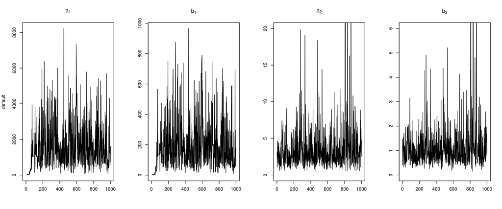

```r
smp_cross <- as.matrix(Cmcmc$mvSamples)

par(mfrow = c(1,4))
ts.plot(smp_cross[ , 'a[1]'], main = expression(a[1]), xlab = '', ylab = 'default')
ts.plot(smp_cross[ , 'b[1]'], main = expression(b[1]), xlab = '', ylab = '')
ts.plot(smp_cross[ , 'a[2]'], main = expression(a[2]), xlab = '', ylab = '', ylim = c(0,20))
ts.plot(smp_cross[ , 'b[2]'], main = expression(b[2]), xlab = '', ylab = '', ylim = c(0,6))
```

```r
effectiveSize(as.mcmc(smp_cross[postBurn, ]))
```

```
##     a[1]     a[2]     b[1]     b[2]  p[1, 1]  p[2, 1]  p[1, 2]  p[2, 2]
## 233.1259 189.7662 227.2099 214.5381 560.7673 697.0399 607.2828 639.9603
##  p[1, 3]  p[2, 3]  p[1, 4]  p[2, 4]  p[1, 5]  p[2, 5]  p[1, 6]  p[2, 6]
## 638.5802 686.2910 557.6990 698.4117 597.4754 919.5277 503.2397 743.8660
##  p[1, 7]  p[2, 7]  p[1, 8]  p[2, 8]  p[1, 9]  p[2, 9] p[1, 10] p[2, 10]
## 646.1498 777.6104 553.7543 663.9339 575.7662 965.0219 529.6785 716.9356
## p[1, 11] p[2, 11] p[1, 12] p[2, 12] p[1, 13] p[2, 13] p[1, 14] p[2, 14]
## 573.2685 824.7858 659.2545 598.9111 624.8026 651.9686 715.9955 645.9188
## p[1, 15] p[2, 15] p[1, 16] p[2, 16]
## 655.0746 630.3340 601.5058 510.7385
```

# Using MCEM

We might also be interested in an empirical Bayes (maximum likelihood for the hyperparameters) analysis. This can be done by Monte Carlo Expectation Maximization, an algorithm that integrates over the random effects numerically using an MCMC sampler for the random effects embedded within an optimization over the hyperparameters.

```r
# currently an issue with running MCEM on the same model as an MCMC
# so create new copy of model
model2 <- model$newModel()
inits <- list( a = c(12, 12), b=c(12, 12) )
model2$setInits(inits)
mcem <- buildMCEM(model2, latentNodes = 'p', burnIn = 250)
print(system.time(   # takes a while:
        out <- mcem()
))
out
```

```
|-------------|-------------|-------------|-------------|
|-------------------------------------------------------|
Iteration Number: 1.
Current number of MCMC iterations: 1000.
Parameter Estimates:
     a[1]      a[2]      b[1]      b[2]
17.128379 10.119031 10.728973  7.596986
Convergence Criterion: 1.001.
|-------------|-------------|-------------|-------------|
|-------------------------------------------------------|
Monte Carlo error too big: increasing MCMC sample size.
|-------------|-------------|-------------|-------------|
|-------------------------------------------------------|
Monte Carlo error too big: increasing MCMC sample size.
|-------------|-------------|-------------|-------------|
|-------------------------------------------------------|
Iteration Number: 2.
Current number of MCMC iterations: 1938.
Parameter Estimates:
     a[1]      a[2]      b[1]      b[2]
16.493028  8.285654  8.668640  5.351970
Convergence Criterion: 5.153947.
|-------------|-------------|-------------|-------------|
|-------------------------------------------------------|

...

Monte Carlo error too big: increasing MCMC sample size.
|-------------|-------------|-------------|-------------|
|-------------------------------------------------------|
Iteration Number: 100.
Current number of MCMC iterations: 43516.
Parameter Estimates:
      a[1]       a[2]       b[1]       b[2]
54.3247654  1.5847327  6.1643360  0.5571288
Convergence Criterion: 0.0004288356.
    user   system  elapsed
4735.884  465.087 4689.447
```

One option to reparameterize the model from the `a,b` parameterization to the mean and standard deviation of the beta distribution. That’s easy in NIMBLE, since we provide that parameterization as an alternative parameterization!

# MCEM with reparameterization

Here we use NIMBLE’s alternative parameterizations to directly represent the beta distribution in terms of mean and standard deviation. Convergence is slow but it does seem to converge to the MLE of $\hat\mu=0.898$ and $\hat\sigma=0.043$.

```r
codeReparam <- nimbleCode({
  for (i in 1:G) {
     for (j in 1:N) {
        r[i,j] ~ dbin(p[i,j], n[i,j]);
        p[i,j] ~ dbeta(mean = mu[i], sd = sigma[i])
     }
     mu[i] ~ dunif(0, 1)
     sigma[i] ~ dunif(0, 1)
   }
})
inits <- list( mu = c(.5, .5), sigma = c(.1, .1))
modelReparam <- nimbleModel(codeReparam, constants = consts, data = data,
             inits = inits)
latents <- modelReparam$getNodeNames(latentOnly = TRUE, stochOnly = TRUE)
mcemReparam <- buildMCEM(modelReparam, latentNodes = latents,
            alpha=.01,beta=.01,gamma=.01)
print(system.time(
        outReparam <- mcemReparam()
))
outReparam
```

```
|-------------|-------------|-------------|-------------|
|-------------------------------------------------------|
Iteration Number: 1.
Current number of MCMC iterations: 1000.
Parameter Estimates:
     mu[1]      mu[2]   sigma[1]   sigma[2]
0.61492694 0.57155388 0.08993834 0.11355390
Convergence Criterion: 1.001.
|-------------|-------------|-------------|-------------|
|-------------------------------------------------------|
Monte Carlo error too big: increasing MCMC sample size.
|-------------|-------------|-------------|-------------|
|-------------------------------------------------------|
Monte Carlo error too big: increasing MCMC sample size.
|-------------|-------------|-------------|-------------|
|-------------------------------------------------------|
Monte Carlo error too big: increasing MCMC sample size.
|-------------|-------------|-------------|-------------|
|-------------------------------------------------------|
Iteration Number: 2.
Current number of MCMC iterations: 2188.
Parameter Estimates:
     mu[1]      mu[2]   sigma[1]   sigma[2]
0.66645160 0.61640212 0.08979572 0.12815343
Convergence Criterion: 6.423049.

...

Monte Carlo error too big: increasing MCMC sample size.
|-------------|-------------|-------------|-------------|
|-------------------------------------------------------|
Iteration Number: 208.
Current number of MCMC iterations: 219536.
Parameter Estimates:
     mu[1]      mu[2]   sigma[1]   sigma[2]
0.89746995 0.73982716 0.04305452 0.24714564
Convergence Criterion: 8.970094e-05.
     user    system   elapsed
13857.238     2.437 13856.241
```